# A3: SPL Library Checkouts

### Introduction

Over the past decade, the Seattle Public Library has meticulously gathered a plethora of checkout data, giving way to new discoveries to analyze the habits of its library-goers. My personal interest concerns the medium in which books are read; ever since the integration of online media, my father and I believed services such as Kindle would skyrocket in popularity and eclipse that of traditional books. With this data, I can determine the success of electronic reading material and compare it to physical copies.

### Summary Information

In particular, a great shift between the two mediums was exhibited in early 2020 due to the COVID-19 pandemic. The Seattle Public Library was forced to prohibit physical checkouts, but continued to operate online. This decision had allowed digital media to skyrocket, especially for e-books; this online reading material soared by 16,196 checkouts within the month of March, the greatest increase it has ever seen.

Going forward, it would seem an emphasis on the digital medium would benefit the Seattle Public Library, particularly e-books, as it has maintained its boosted popularity since COVID-19 to become the most consumed form of library material.

### The Dataset

As mentioned, the Seattle Public Library collected and published the data used for these findings. The data consists of 4224916 observations and 12 distinct features: UsageClass, either physical or digital media; CheckoutType, the medium in which the material was checked out through; MaterialType, the specific form of the content (ebook, video disc, etc.); CheckoutYear, CheckoutMonth, Title, ISBN, Creator, Subjects, Publisher PublicationYear.

The data was first collected in 2005 by an artist who was working independently for an art installation involving library checkouts. However, the first initiative to create an open source database for previously private government resources was under the presidency of Barack Obama. Ever since 2017, library checkouts (including those collected by the professor) have been documented and shared publicly for use.

The most notable ethical question has to do with privacy; library-goers should have the right to checkout reading material without the worry of being flagged or spied on. In fact, the Seattle Public Library was one of the first libraries to implement sharing data due to the uneasy nature of publicizing personal information. The SPL got around this problem by de-identifying the checkouts so that no piece of data can be tied to one person.

There are a number of limitations with this data; because the checkout data is de-identified from the library-goer, it is difficult to draw meaningful conclusions from checkout data alone. For instance, digital content can be checked out by several people at the same time; yet, this is not accounted for in the data as an effort to remove the people from the equation. In order to respect privacy, a price had to be paid in the form less applicable data.

### SPL Checkouts of E-Books and Audiobooks from 2013 to 2023

Much of the motivation for the graph below is explained above in the summary. The most notable pattern is that digital content has been on the rise ever since 2013. There is a noticeable peak at the start of 2020 due the COVID-19 pandemic, a point of equal interest with the graph below.

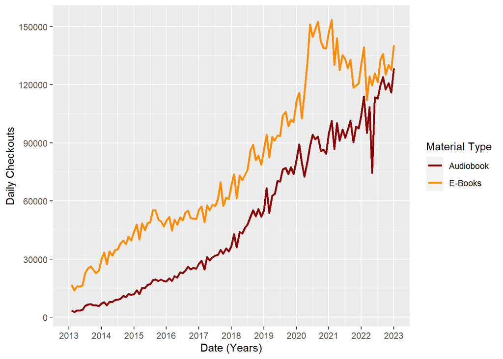

### SPL Checkouts of Books, Sound Discs, and Video Discs from 2013 to 2023

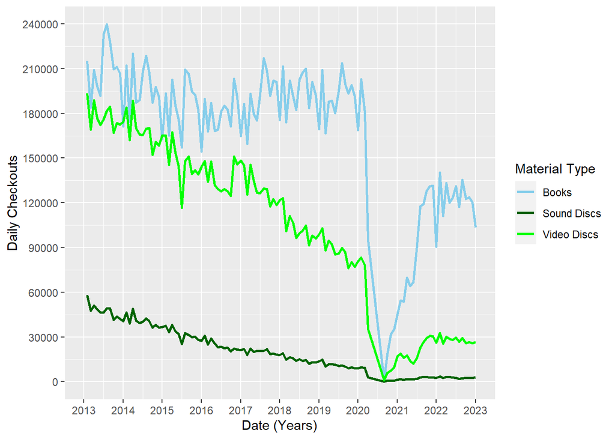

### SPL Checkouts of Physical and Digital Media from 2013 to 2023

Much of the motivation for the graph below is explained above in the summary. It is clear that the start of the COVID-19 pandemic was a dramamtic shift between the dominance of digital media over physical media.

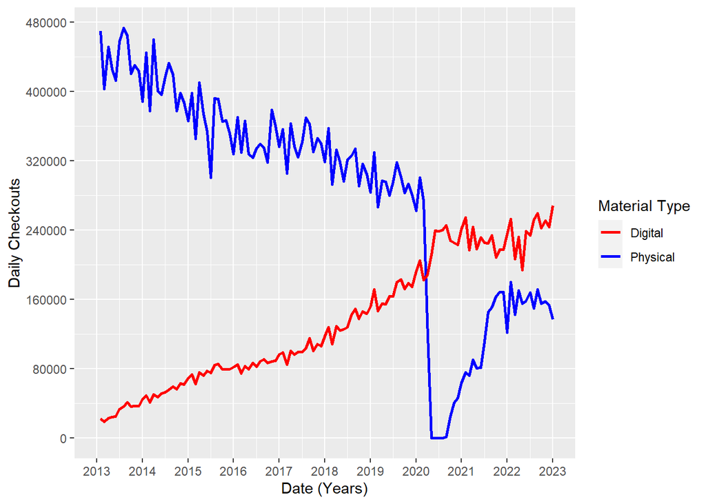